# Personal Website

Jeremy D Harris, PhD, Applied Mathematics, [CV](https://github.com/Jeremy-D-Harris/cv_jdh_2022/blob/main/CV_JDH_Feb2023.pdf)

- About
  - Weblinks
- Research
  - Weitz Lab (2020-Present)
  - Koelle lab (2017-2020)
  - Recent Publications
- Teaching
  - Rose-Hulman
  - Georgia Tech

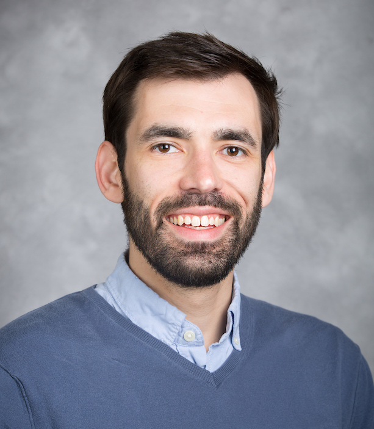

[Visiting Assistant Professor](https://www.rose-hulman.edu/academics/academic-departments/mathematics/faculty-and-staff.html)  
Mathematics  
Rose-Hulman Institute of Technology, Terre Haute, IN

## About

I got my PhD in Applied Math from University of Pittsburgh, where I studied spatiotemporal patterns in neural firing rate models, advised by [Professor Bard Ermentrout](https://sites.pitt.edu/~phase/). I did my first postdoc in biology at Emory University, supervised by [Professor Katia Koelle](https://scholarblogs.emory.edu/koellelab/group-members/) (2017-2020), where I began studying virus-host dynamics. Before moving into my current position at [Rose-Hulman](https://www.rose-hulman.edu/academics/academic-departments/mathematics/index.html), I did a postdoc in the [Weitz lab](https://weitzgroup.biosci.gatech.edu/) at GA Tech in biological sciences, continuting to study virus-host dynamics both across systems and scales: from COVID epidemic dynamics to phage-host dynamics (viruses infecting bacteria).

#### Weblinks

- [Recent publication (!) out of the Koelle Lab](https://academic.oup.com/mbe/article/41/1/msad286/7504375?login=false)
- [github](https://github.com/Jeremy-D-Harris/)
- [linkedin](https://www.linkedin.com/in/jeremy-d-harris)
- [orcid](https://orcid.org/0000-0002-6836-3620)

## Research

I use math models to study the ecology and evolution of infectious diseases. Infectious diseases occur often occur across multiple scales. For instance, in epidemics models there is the individual level, where transmission is often quantified by the reproduction number, $R_0$ (“strength”) and the population level, where transmission is quantifed by the observed exponential growth rate of new cases, “$r$” (“speed”). Hence, models can be used to bridge these scales, telling us about *hidden variables* from those observed.

#### Weitz Lab (2020-Present)

- **epidemic models**
  - asymptomatic transmission in COVID-19 using a generation interval framework ([publication in the journal Epidemics (2023)](https://www.sciencedirect.com/science/article/pii/S1755436522001049)!)

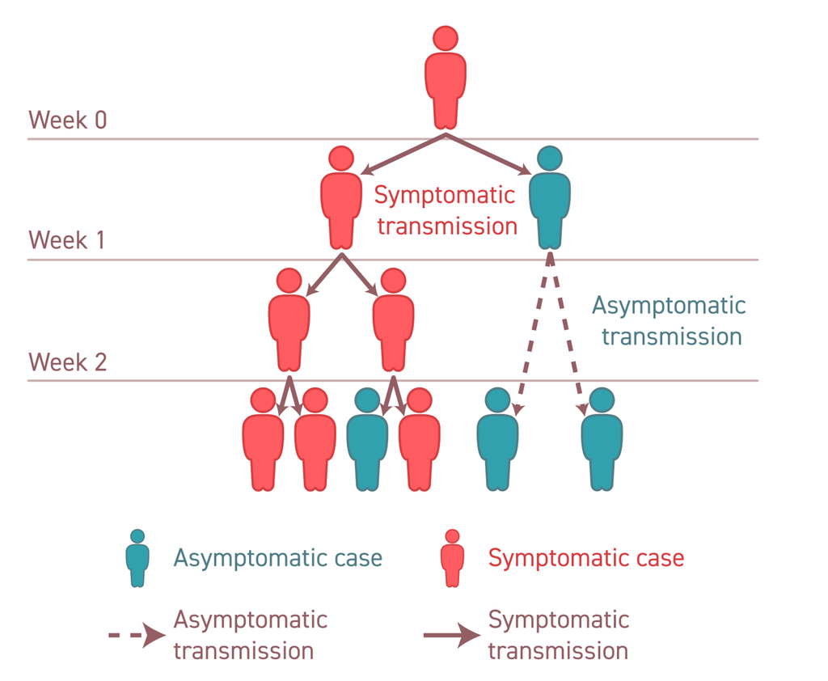

    Designed by Audra Davidson
- **virus-microbe dynamics and entanglement problems**
  - latent period variability in one-step experiments (coming soon!)
  - phage-host coalitions (eco-evoluationary spatial dyanmics!)

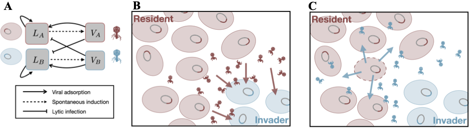

#### Koelle lab (2017-2020)

- **cell coinfection of influenza A virus**
  - modeling cellular responses to multiple infections in influenza ([publication in the journal PLOS Pathogens (2020)](https://journals.plos.org/plospathogens/article?id=10.1371/journal.ppat.1008974))

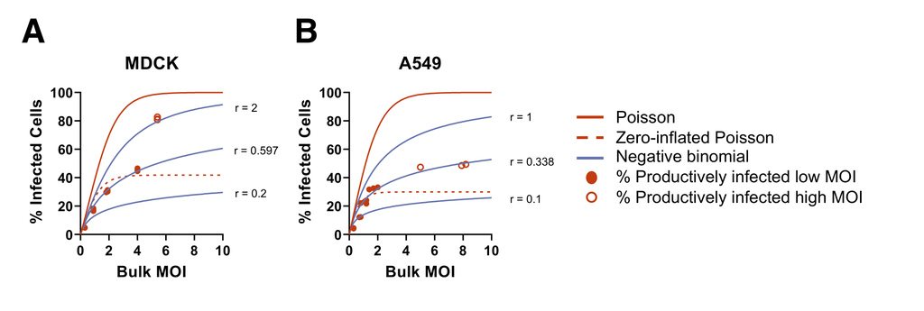

    Comparison of infection distibutions with respect to percent of infected cells in MDCK (A) vs. A549 (B) cell types.

#### Recent Publications

- Harris, J. D.* , Park, S. W.*, Dushoff, J., & Weitz, J. S. (2023). How time-scale differences in asymptomatic and symptomatic transmission shape SARS-CoV-2 outbreak dynamics. Epidemics, 100664. ([DOI](https://doi.org/10.1016/j.epidem.2022.100664))
- Martin, B. E.* , Harris, J. D. *, Sun, J., Koelle, K., & Brooke, C. B. (2020). Cellular co-infection can modulate the efficiency of influenza A virus production and shape the interferon response. PLoS pathogens, 16(10), e1008974. ([DOI](https://doi.org/10.1371/journal.ppat.1008974))

*these folks contributed equally

## Teaching

### Rose-Hulman

- Diff Eq 1 (Fall & Winter Quarters 2023)
  - [Lecture Notes](https://github.com/Jeremy-D-Harris/Teaching/blob/main/DiffEq1_LectureNotes_Winter2023.pdf)
- Calc 2 (Winter Quarter 2023)

### Georgia Tech

- [QBioS Foundations Course](https://qbios.gatech.edu/course-information) (Fall 2021 & 2022)  
  Modules taught:
  - organismal behavior & sensing
  - excitability – neurons
  - excitability – cardiac cells
  - biomechanics of movement
- [ICTP-SAIFR Training Program in Quantitative Biology and Ecology](https://www.ictp-saifr.org/qbioprogram/) (Summer 2022)  
  Module taught:
  - organismal behavior & sensing